# CSCI E-63C Week 10 Problem Set

# Preface

For this week problem set we will use WiFi localization data (the one we worked with on week 2) to fit logistic regression model and evaluate performance of LDA, QDA and KNN classifiers. As we have seen earlier this dataset should allow to locate phones fairly well by relying on the strength of WiFi signal, so we should expect to see fairly low error rates for our classifiers. Let’s see whether some of those classifiers perform better than others on this data.

**Important note:** *For the purposes of all problems in this week problem set, we will be predicting whether the phone is at location=3 or not, as opposed to working with multi-class predictor. In other words, before you proceed with any of the problems in this assignment, please convert the four-levels outcome to the outcome with only two levels: location=3 (must be 500 of those) and not (must be 1500 of them).*

*If you are creating a new column containing this binary outcome, please make sure that the original outcome with four columns is NOT used inadvertently as one of the predictors. If you are getting invariably 100% accuracy regardless of the choice of the method or split of the data into training and test, chances are your code is using original four-levels outcome as a predictor.*

```r
raw.data <- read.csv("wifi_localization.txt", sep="\t", header = FALSE)
head(raw.data)
```

```
##    V1  V2  V3  V4  V5  V6  V7 V8
## 1 -64 -56 -61 -66 -71 -82 -81  1
## 2 -68 -57 -61 -65 -71 -85 -85  1
## 3 -63 -60 -60 -67 -76 -85 -84  1
## 4 -61 -60 -68 -62 -77 -90 -80  1
## 5 -63 -65 -60 -63 -77 -81 -87  1
## 6 -64 -55 -63 -66 -76 -88 -83  1
```

```r
raw.data$V8[raw.data$V8 != 3] <- 0
raw.data$V8[raw.data$V8 == 3] <- 1
colnames(raw.data) <- c("X1", "X2", "X3", "X4", "X5", "X6", "X7", "Y")
head(raw.data)
```

```
##    X1  X2  X3  X4  X5  X6  X7 Y
## 1 -64 -56 -61 -66 -71 -82 -81 0
## 2 -68 -57 -61 -65 -71 -85 -85 0
## 3 -63 -60 -60 -67 -76 -85 -84 0
## 4 -61 -60 -68 -62 -77 -90 -80 0
## 5 -63 -65 -60 -63 -77 -81 -87 0
## 6 -64 -55 -63 -66 -76 -88 -83 0
```

```r
summary(raw.data)
```

```
##        X1               X2               X3               X4
##  Min.   :-74.00   Min.   :-74.00   Min.   :-73.00   Min.   :-77.00
##  1st Qu.:-61.00   1st Qu.:-58.00   1st Qu.:-58.00   1st Qu.:-63.00
##  Median :-55.00   Median :-56.00   Median :-55.00   Median :-56.00
##  Mean   :-52.33   Mean   :-55.62   Mean   :-54.96   Mean   :-53.57
##  3rd Qu.:-46.00   3rd Qu.:-53.00   3rd Qu.:-51.00   3rd Qu.:-46.00
##  Max.   :-10.00   Max.   :-45.00   Max.   :-40.00   Max.   :-11.00
##        X5               X6               X7               Y
##  Min.   :-89.00   Min.   :-97.00   Min.   :-98.00   Min.   :0.00
##  1st Qu.:-69.00   1st Qu.:-86.00   1st Qu.:-87.00   1st Qu.:0.00
##  Median :-64.00   Median :-82.00   Median :-83.00   Median :0.00
##  Mean   :-62.64   Mean   :-80.98   Mean   :-81.73   Mean   :0.25
##  3rd Qu.:-56.00   3rd Qu.:-77.00   3rd Qu.:-78.00   3rd Qu.:0.25
##  Max.   :-36.00   Max.   :-61.00   Max.   :-63.00   Max.   :1.00
```

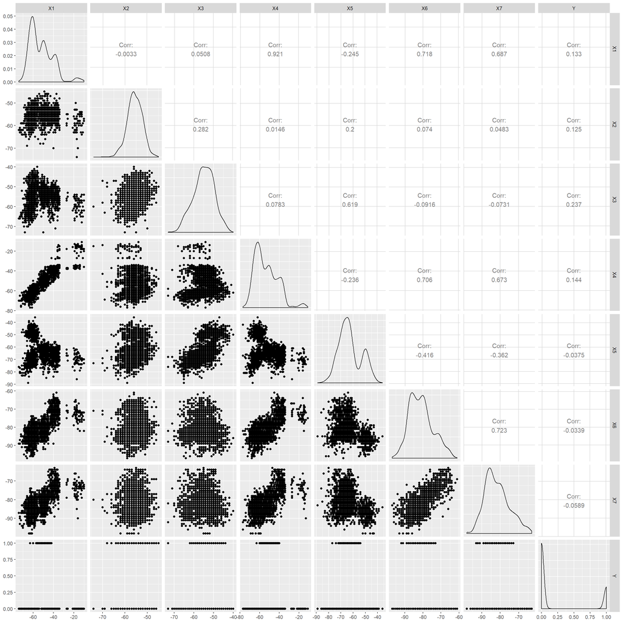

```r
library(ggplot2)
library(GGally)
ggpairs(raw.data, progress = FALSE)
```

# Problem 1 (10 points): logistic regression

Fit logistic regression model of the binary categorical outcome (location=3 or not) using seven WiFi signals strengths as predictors in the model. Produce summary of the model, describe which attributes appear to be significantly associated with the categorical outcome in this model. Use this model to make predictions on the entire dataset and compare these predictions and corresponding true values of the class attribute using confusion matrix (i.e. contingency table). Calculate error rate (would this be training or test error in this case?), sensitivity and specificity (assuming that we are predicting class “location=3”). Describe the results.

```r
glm.fit=glm(Y~., data = raw.data, family = binomial)
summary(glm.fit)
```

```
##
## Call:
## glm(formula = Y ~ ., family = binomial, data = raw.data)
##
## Deviance Residuals:
##      Min        1Q    Median        3Q       Max
## -2.25602  -0.69944  -0.41966   0.06246   2.52634
##
## Coefficients:
##             Estimate Std. Error z value Pr(>|z|)
## (Intercept) -5.84266    1.53114  -3.816 0.000136 ***
## X1           0.06149    0.01376   4.471 7.80e-06 ***
## X2           0.11270    0.01875   6.011 1.84e-09 ***
## X3           0.21847    0.01679  13.014  < 2e-16 ***
## X4           0.04002    0.01324   3.022 0.002513 **
## X5          -0.13188    0.01061 -12.427  < 2e-16 ***
## X6          -0.12960    0.01590  -8.153 3.56e-16 ***
## X7          -0.11333    0.01425  -7.952 1.83e-15 ***
## ---
## Signif. codes:  0 '***' 0.001 '**' 0.01 '*' 0.05 '.' 0.1 ' ' 1
##
## (Dispersion parameter for binomial family taken to be 1)
##
##     Null deviance: 2249.3  on 1999  degrees of freedom
## Residual deviance: 1792.0  on 1992  degrees of freedom
## AIC: 1808
##
## Number of Fisher Scoring iterations: 5
```

All predictor variables are significant in for predicting the outcome. X4 is the least significant with a p-value of 0.002513 and X3 and X5 are the most significant with p-values less than 2e-16.

```r
glm.predict <- predict(glm.fit, newdata=raw.data[,1:7], type = "response")
```

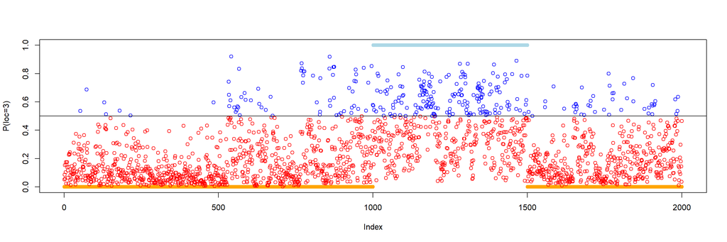

```r
plot(raw.data$Y, col=ifelse(raw.data$Y==1, "lightblue", "orange"),ylab = "P(loc=3)")
points(glm.predict, col = ifelse(glm.predict>=0.5, "blue", "red"))
abline(h=0.5)
```

```r
assess.prediction=function(truth,predicted) {
   # same length:
   if ( length(truth) != length(predicted) ) {
     stop("truth and predicted must be same length!")
   }
   # check for missing values (we are going to
   # compute metrics on non-missing values only)
   bKeep = ! is.na(truth)  & ! is.na(predicted)
   predicted = predicted[ bKeep ]
   truth = truth[ bKeep ]
   # only 0 and 1:
   if ( sum(truth%in%c(0,1))+sum(predicted%in%c(0,1))!=2*length(truth) ) {
     stop("only zeroes and ones are allowed!")
   }
   cat("Total cases that are not NA: ",
         length(truth),"\n",sep="")
   # overall accuracy of the test: how many cases
   # (both positive and
   # negative) we got right:
   cat("Correct predictions (accuracy): ",
     sum(truth==predicted),
     "(",signif(sum(truth==predicted)*100/
     length(truth),3),"%)\n",sep="")
   # how predictions align against known
   # training/testing outcomes:
   # TP/FP= true/false positives,
   # TN/FN=true/false negatives
   TP = sum(truth==1 & predicted==1)
   TN = sum(truth==0 & predicted==0)
   FP = sum(truth==0 & predicted==1)
   FN = sum(truth==1 & predicted==0)
   P = TP+FN  # total number of
         # positives in the truth data
   N = FP+TN  # total number of
              # negatives
   cat("TP, TN, FP, FN, P, N:",TP, TN, FP, FN, P, N, fill=TRUE)
   cat("TPR (sensitivity)=TP/P: ",
       signif(100*TP/P,3),"%\n",sep="")
   cat("TNR (specificity)=TN/N: ",
       signif(100*TN/N,3),"%\n",sep="")
   cat("PPV (precision)=TP/(TP+FP): ",
       signif(100*TP/(TP+FP),3),"%\n",sep="")
   cat("FDR (false discovery)=1-PPV: ",
       signif(100*FP/(TP+FP),3),"%\n",sep="")
   cat("FPR =FP/N=1-TNR: ",
      signif(100*FP/N,3),"%\n",sep="")
}
```

```r
glm.predict[glm.predict >= 0.5] <- 1
glm.predict[glm.predict < 0.5] <- 0
```

```r
assess.prediction(raw.data$Y, glm.predict)
```

```
## Total cases that are not NA: 2000
## Correct predictions (accuracy): 1563(78.2%)
## TP, TN, FP, FN, P, N: 178 1385 115 322 500 1500
## TPR (sensitivity)=TP/P: 35.6%
## TNR (specificity)=TN/N: 92.3%
## PPV (precision)=TP/(TP+FP): 60.8%
## FDR (false discovery)=1-PPV: 39.2%
## FPR =FP/N=1-TNR: 7.67%
```

This model only predicts whether a phone is truly at location 3 only 35.6% of the time which is relatively poor.

It does predict which phone are truly not at location 3 92.3% of the time however which is fairly good.

The false discovery rate of 39.2% means that almost 4/10 phones are misidentified as being at location 3 even though they are not in reality.

In summary, the model relatively accurately can tell you what phone are not at location 3 but cannot reliably predict which phones are at location 3. Overall it accuratley predicts if a phone is at location 3 or not 78.2% of the time.

The training error rate is given by 1 - accuracy = 21.8%. Because the original data was used as the test data, it is actually the training error rate.

# Problem 2 (10 points): LDA and QDA

Using LDA and QDA implementations available in the package `MASS`, fit LDA and QDA classifiers on the entire dataset and calculate confusion matrix, (training) error rate, sensitivity and specificity for each of them. Compare them to those of logistic regression. Describe the results.

```r
library(MASS)
```

```r
lda.fit <- lda(Y~., data=raw.data)
lda.fit
```

```
## Call:
## lda(Y ~ ., data = raw.data)
##
## Prior probabilities of groups:
##    0    1
## 0.75 0.25
##
## Group means:
##          X1        X2        X3        X4        X5        X6        X7
## 0 -53.19867 -55.86933 -55.69067 -54.52133 -62.44333 -80.85733 -81.50467
## 1 -49.72600 -54.88600 -52.78400 -50.70200 -63.23200 -81.36800 -82.39200
##
## Coefficients of linear discriminants:
##            LD1
## X1  0.05158262
## X2  0.09479913
## X3  0.18077050
## X4  0.03719523
## X5 -0.11372527
## X6 -0.10837140
## X7 -0.09870481
```

```r
lda.predict <- predict(lda.fit, newdata = raw.data[,1:7])
```

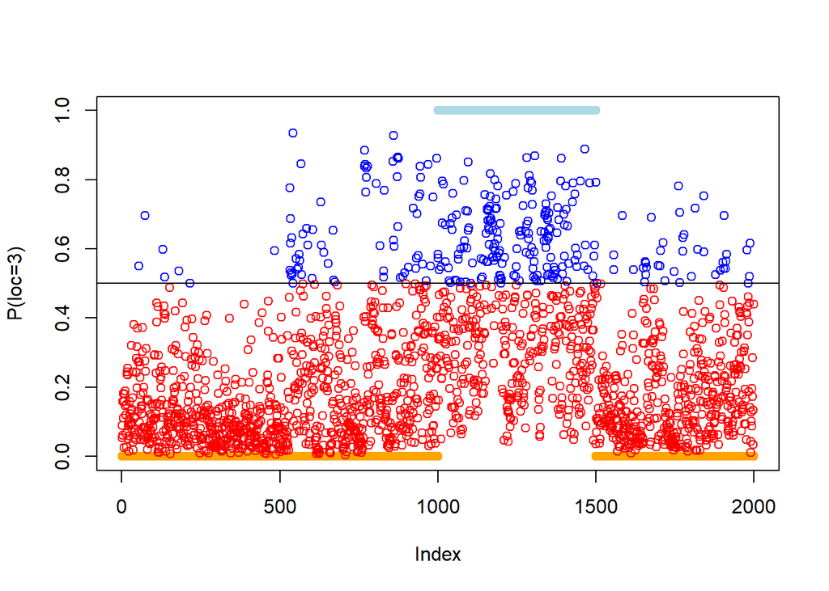

```r
plot(raw.data$Y, col=ifelse(raw.data$Y==1, "lightblue", "orange"),ylab = "P(loc=3)")
points(lda.predict$posterior[,2], col = ifelse(lda.predict$posterior[,2]>=0.5, "blue", "red"))
abline(h=0.5)
```

```r
assess.prediction(raw.data$Y, lda.predict$class)
```

```
## Total cases that are not NA: 2000
## Correct predictions (accuracy): 1561(78%)
## TP, TN, FP, FN, P, N: 179 1382 118 321 500 1500
## TPR (sensitivity)=TP/P: 35.8%
## TNR (specificity)=TN/N: 92.1%
## PPV (precision)=TP/(TP+FP): 60.3%
## FDR (false discovery)=1-PPV: 39.7%
## FPR =FP/N=1-TNR: 7.87%
```

The results of the LDA classification is very similar to the logistic regression. The sensitivity, spedificity and precision vary by only a few tenths of a percent. The overall accuracy is very similar as well at 78%.

Visually, the plot looks identical to the logistic regression as well.

```r
qda.fit <- qda(Y~., data=raw.data)
qda.fit
```

```
## Call:
## qda(Y ~ ., data = raw.data)
##
## Prior probabilities of groups:
##    0    1
## 0.75 0.25
##
## Group means:
##          X1        X2        X3        X4        X5        X6        X7
## 0 -53.19867 -55.86933 -55.69067 -54.52133 -62.44333 -80.85733 -81.50467
## 1 -49.72600 -54.88600 -52.78400 -50.70200 -63.23200 -81.36800 -82.39200
```

```r
qda.predict <- predict(qda.fit, newdata = raw.data[,1:7])
```

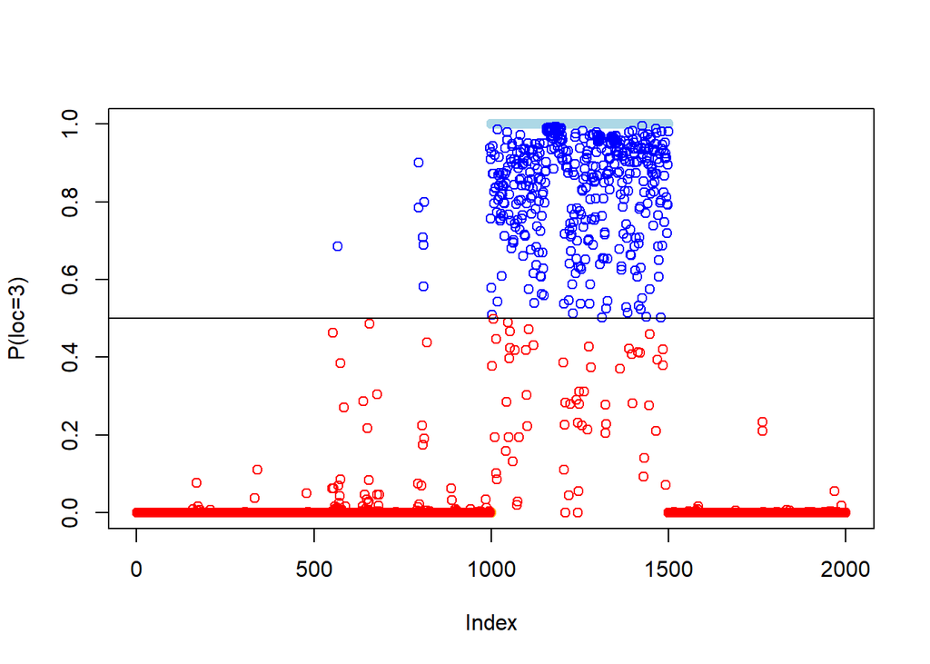

```r
plot(raw.data$Y, col=ifelse(raw.data$Y==1, "lightblue", "orange"),ylab = "P(loc=3)")
points(qda.predict$posterior[,2], col = ifelse(qda.predict$posterior[,2]>=0.5, "blue", "red"))
abline(h=0.5)
```

```r
assess.prediction(raw.data$Y, qda.predict$class)
```

```
## Total cases that are not NA: 2000
## Correct predictions (accuracy): 1930(96.5%)
## TP, TN, FP, FN, P, N: 441 1489 11 59 500 1500
## TPR (sensitivity)=TP/P: 88.2%
## TNR (specificity)=TN/N: 99.3%
## PPV (precision)=TP/(TP+FP): 97.6%
## FDR (false discovery)=1-PPV: 2.43%
## FPR =FP/N=1-TNR: 0.733%
```

This model has a much higher sensitivity rate than the logistic and lda models at 88.2%.

The specificity rate is even higher as well at 99.3%.

The false discovery rate only 2.43%.

Overall this is a quality model with good prediction outcomes and low false positive and false negative rates. The overall accuracy is 96.5% on the training data.

Visually, the model looks to be plotting the locations very accurately as well.

The model does struggle more with failing to detect phone in location 3 more than it does detecting phone in other locations with is indicated by two things: The TPR rate being lower thatn the TNR rate and the proportion of red circles between indices 1000 and 1500 as compared to the blue circles from 0 to 1000 and 1500 to 2000.

This is the best model so far.

# Problem 3 (10 points): KNN

Using `knn` from library `class`, fit KNN classifiers for the entire dataset and calculate confusion matrix, (training) error rate, sensitivity/specificity for $k=1$, $5$ and $25$ nearest neighbors models. Compare them to the corresponding results from LDA, QDA and logistic regression. Describe results of this comparison and discuss whether it is surprising to see low *training* error for KNN classifier with $k=1$.

```r
library(class)
```

```r
knn.pred.1 <- knn(train = raw.data[,1:7], test = raw.data[,1:7], cl=raw.data$Y)
knn.pred.5 <- knn(train = raw.data[,1:7], test = raw.data[,1:7], cl=raw.data$Y, k=5)
knn.pred.25 <- knn(train = raw.data[,1:7], test = raw.data[,1:7], cl=raw.data$Y, k=25)
```

```r
#offset prediction values to plot
knn.pred.1.adj <- as.numeric(knn.pred.1)-1
knn.pred.1.adj[knn.pred.1.adj==1] <- 0.95
knn.pred.1.adj[knn.pred.1.adj==0] <- 0.05

knn.pred.5.adj <- as.numeric(knn.pred.5)-1
knn.pred.5.adj[knn.pred.5.adj==1] <- 0.95
knn.pred.5.adj[knn.pred.5.adj==0] <- 0.05

knn.pred.25.adj <- as.numeric(knn.pred.25)-1
knn.pred.25.adj[knn.pred.25.adj==1] <- 0.95
knn.pred.25.adj[knn.pred.25.adj==0] <- 0.05
```

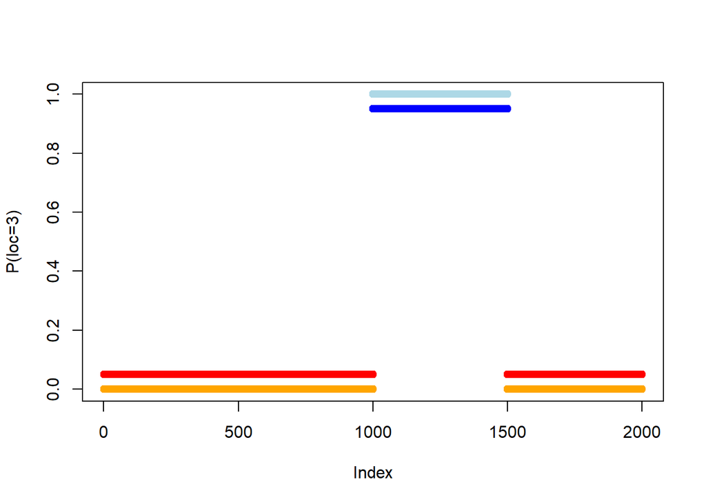

```r
plot(raw.data$Y, col=ifelse(raw.data$Y==1, "lightblue", "orange"), ylab = "P(loc=3)")
points(knn.pred.1.adj, col=ifelse(knn.pred.1.adj>=0.5, "blue", "red"))
```

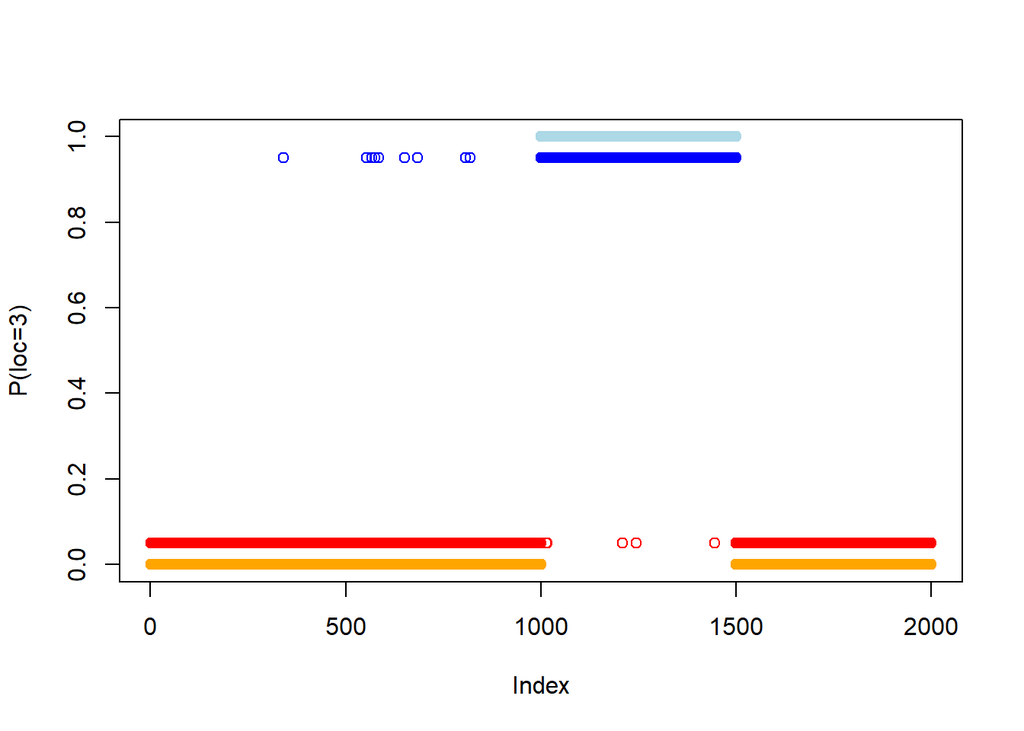

```r
plot(raw.data$Y, col=ifelse(raw.data$Y==1, "lightblue", "orange"), ylab = "P(loc=3)")
points(knn.pred.5.adj, col=ifelse(knn.pred.5.adj>=0.5, "blue", "red"))
```

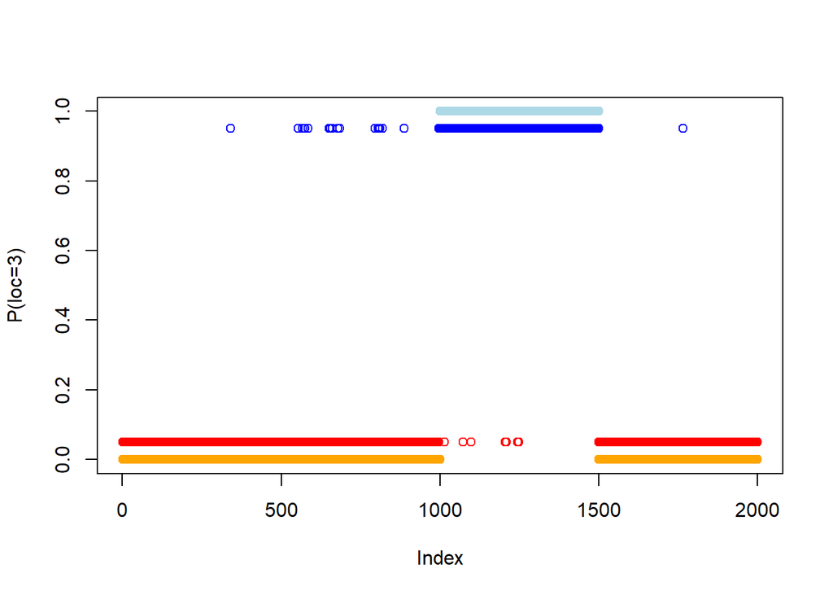

```r
plot(raw.data$Y, col=ifelse(raw.data$Y==1, "lightblue", "orange"), ylab = "P(loc=3)")
points(knn.pred.25.adj, col=ifelse(knn.pred.25.adj>=0.5, "blue", "red"))
```

```r
assess.prediction(raw.data$Y, knn.pred.1)
```

```
## Total cases that are not NA: 2000
## Correct predictions (accuracy): 2000(100%)
## TP, TN, FP, FN, P, N: 500 1500 0 0 500 1500
## TPR (sensitivity)=TP/P: 100%
## TNR (specificity)=TN/N: 100%
## PPV (precision)=TP/(TP+FP): 100%
## FDR (false discovery)=1-PPV: 0%
## FPR =FP/N=1-TNR: 0%
```

```r
assess.prediction(raw.data$Y, knn.pred.5)
```

```
## Total cases that are not NA: 2000
## Correct predictions (accuracy): 1986(99.3%)
## TP, TN, FP, FN, P, N: 495 1491 9 5 500 1500
## TPR (sensitivity)=TP/P: 99%
## TNR (specificity)=TN/N: 99.4%
## PPV (precision)=TP/(TP+FP): 98.2%
## FDR (false discovery)=1-PPV: 1.79%
## FPR =FP/N=1-TNR: 0.6%
```

```r
assess.prediction(raw.data$Y, knn.pred.25)
```

```
## Total cases that are not NA: 2000
## Correct predictions (accuracy): 1962(98.1%)
## TP, TN, FP, FN, P, N: 490 1472 28 10 500 1500
## TPR (sensitivity)=TP/P: 98%
## TNR (specificity)=TN/N: 98.1%
## PPV (precision)=TP/(TP+FP): 94.6%
## FDR (false discovery)=1-PPV: 5.41%
## FPR =FP/N=1-TNR: 1.87%
```

The knn with k=1 1 model has a perfect accuracy, sensitivity, specificity and precision scores of 100%.

The training error rate is the complement of accuracy which is 0%. This is not surprising given that the prediction dataset was the training data set. KNN models with multi dimensions are more suseptible to overfitting because the number of unique distances is so specific at higher dimensionality. This is especially true when using just one neighbor to perform the calculation because each prediction is relying soley on the value of only one data point.

The knn with k=25 performed slightly less well as compared to both the k=5 and k=1 model but the sensitivity, specificity and all still above 98%. The training error was 1.9%.